# Presentation

## Bike circulation and seasonal usage

Firstly, let’s look at the rental bikes usage in 2018.

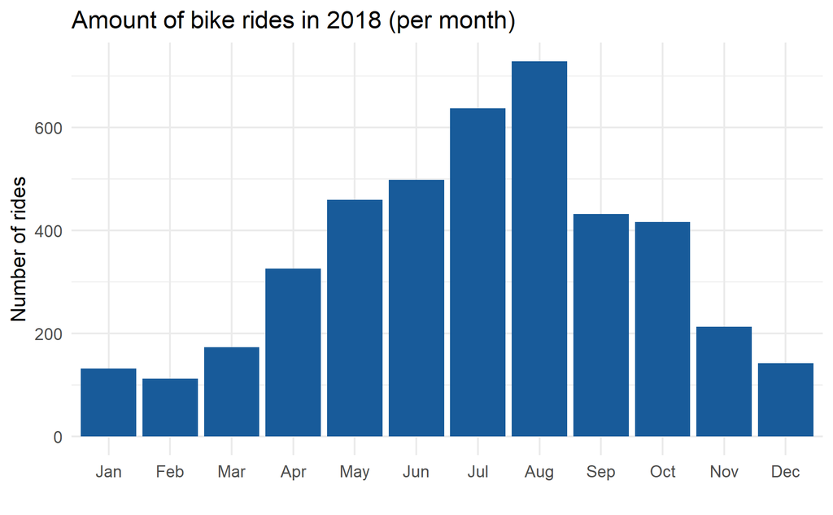

From here, we can see that the usage is lower during winter months. To find the reasons of it, let’s look at the monthly usage of each of 10 availiable bikes.

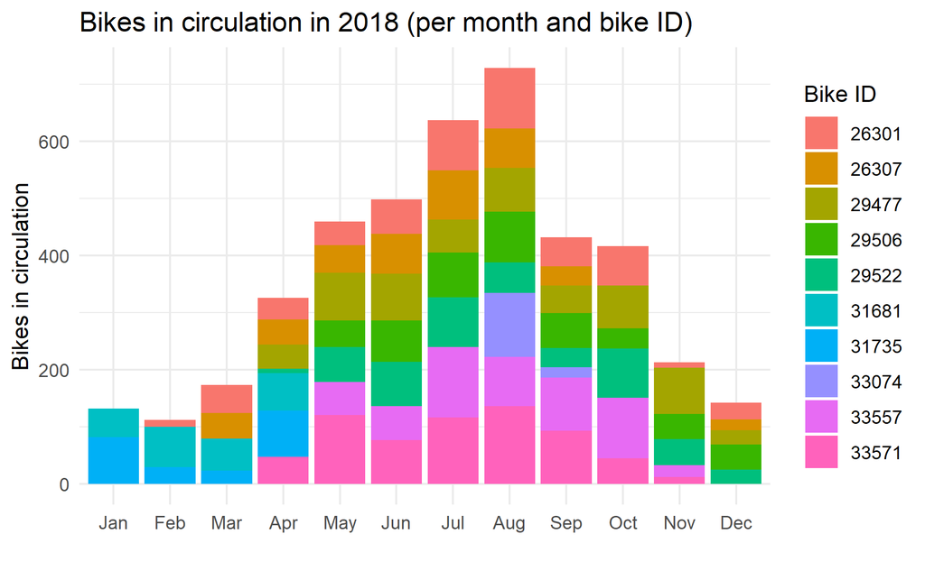

From this visualisation, we can see that it is true that the usage of each separate bike is lower during winter months (probably due to weather conditions, as winters in New York may be icy and snowy). However, we also see that not all 10 bikes were in circulation during full year (maybe they were broken or stolen or lost in another way). Let’s see how many bikes our of our 10-bike sample were in circulation in each month.

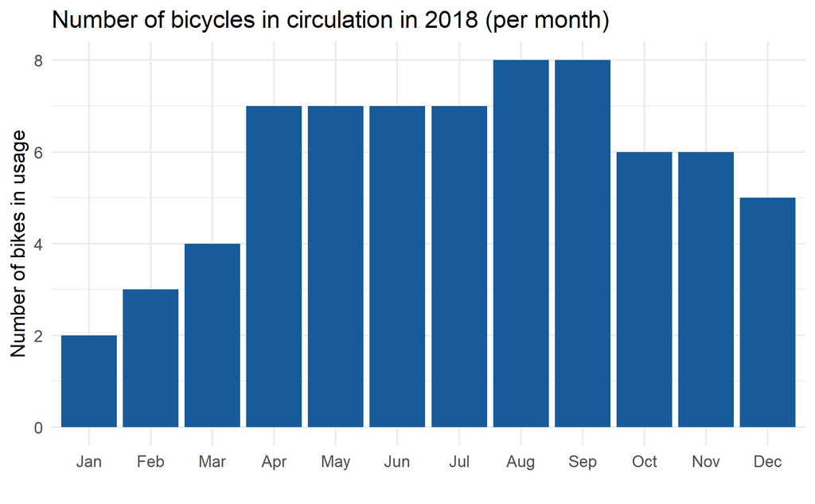

Now, we can see that lower usage in winter months is explained not only by weather, but also by lower number of bikes. Unfortunately, we can only guess why some bikes disappeared from circulation. It requires an additional targeted research.

## Timetables

Let’s have a look on bike usage over day and night. For this part of research, we are going to use all the availiable data (including the 1969 peak data).

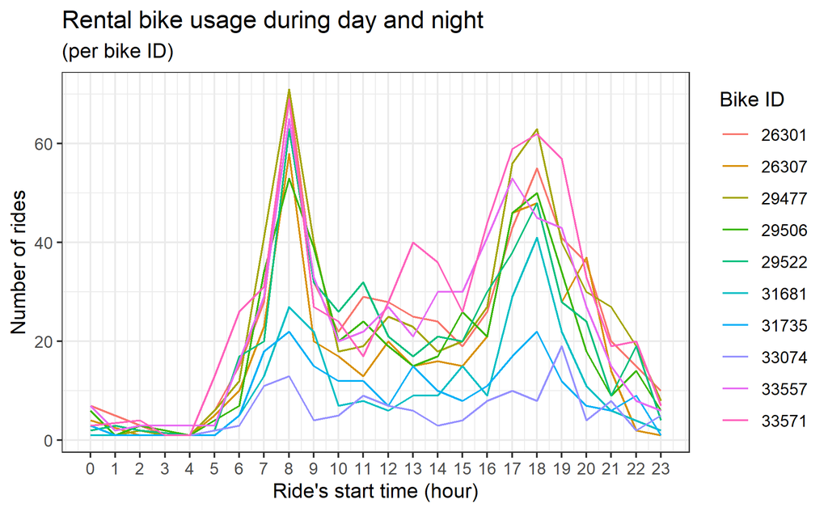

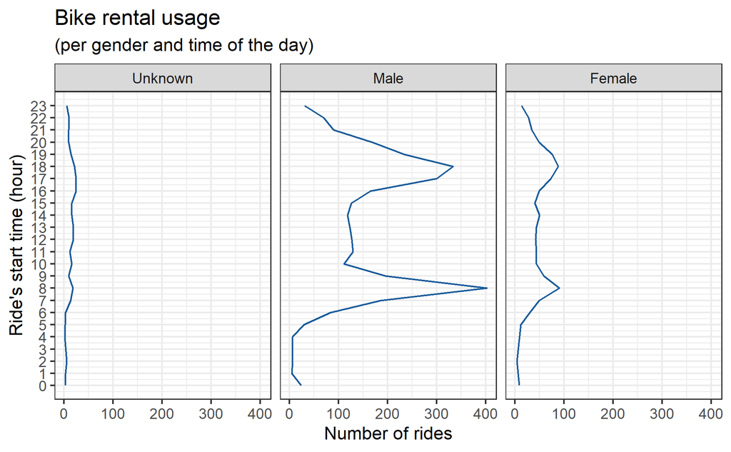

## Demographics

Let’s look at the age of our customers

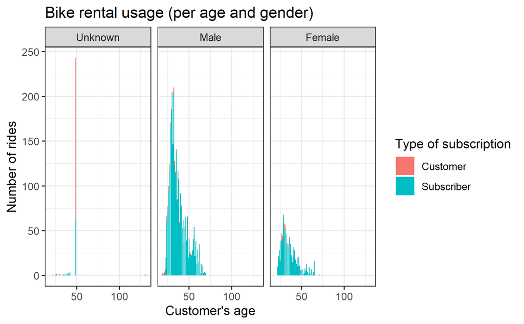

We can see an abnormal spike of customers with unknown gender born in 1969. Also, we can see some people older than 100 years. For the demographic research, we are going to filter the data: take into account only people born after 1940, and also remove everyone born in 1969 with unwkown gender.

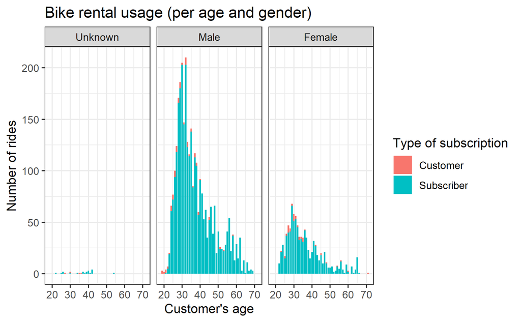

We can see that the majority of our customers are between 25 and 45 years old, and the majority are men. Let’s see at what time of the day (or night) they use the bikes (for simplisity, let’s divide them into age groups.

[figure not shown]

Here, we can clearly see two interesting things:  
1. Women aren’t keen to use rental bikes during night hours.  
2. The 65+ age group also prefer using the bikes only during daytime, and also they are mostly men.  
Assumption: safety issues in both scenario?

## Location

plot1 <- nyc_bikes_ageline %>% filter(start_hour == 8) %>% leaflet() %>% addTiles() %>% addCircleMarkers(lng = ~start_long, lat = ~start_lat)

plot2 <- nyc_bikes_ageline %>% filter(end_hour == 18) %>% leaflet() %>% addTiles() %>% addCircleMarkers(lng = ~start_long, lat = ~start_lat)

## Conclusions: rcommended further research

1. The reason for the drop of usage in winter months is not only less rentals, but also fewer bikes. It is difficult to make conslusions about the bikes’ life-cycle on the sample of 10 bikes and 12 months rental data, but there is a clear possibility for further research.
2. Women, as well as older people, not only use rental bikes less, but also rarely use them during night hours. It is a possible highlight of some safely issues.